# Examen Bioinformatica 2022

Jon Santamaria

1/31/2022

## Comandos de Linux.

1. (2 puntos) Tengo un fichero llamado genes.txt con 3 columnas: Nombre_ de_ gen, cromosoma y posición. Separados por tabulados. ¿Qué comando utilizarías para saber?:
1. ¿Cuántas palabras hay en el fichero?

```r
# cat genes.txt | wc -l
```

2. ¿Cómo cambiarías todos los tabulados por guiones?

```r
# cat genes.txt | sed 's/\/-/g'
```

3. ¿Cómo cambiarías solo la primera aparición?

```r
# cat genes.txt | sed 's/\t/-/'
```

4. ¿Cómo buscarías todos los genes excepto el gen llamado DSTYK?

```r
# cat genes.txt | -v grep DSTYK
```

## Con el dataset llamado weather responde a las siguientes preguntas:

2. Preguntas básicas:
1. (0.5 puntos) ¿Cuántas columnas y cuántos registros tiene este dataset?

```r
library(nycflights13)
library(tidyverse)
library(lubridate)
tiempo=nycflights13::weather
a=dim(tiempo) # tambien se puede hacer con nrow(tiempo) y ncol(tiempo)
print(paste0("El número de registros es ", a[1], " y el número de columnas es ", a[2]))
```

```
## [1] "El número de registros es 26115 y el número de columnas es 15"
```

2. (0.5 puntos) ¿Cuántos “origin” diferentes existen y para cada uno de ellos cuántos registros hay?

```r
table(tiempo$origin)
```

```
##
##  EWR  JFK  LGA
## 8703 8706 8706
```

3. (0.5 puntos) En LGA, ¿cuáles fueron la mediana del wind_speed y media de pressure?

```r
LGA= tiempo[tiempo$origin== "LGA",]
median_LGA_wind_speed= median(LGA$wind_speed)
media_LGA_pressure= mean(LGA$pressure, na.rm = T)
print(paste0("En LGA, la mediana de wind_speed es ", median_LGA_wind_speed, " y la media de pressure es ", media_LGA_pressure))
```

```
## [1] "En LGA, la mediana de wind_speed es 10.35702 y la media de pressure es 1017.67816091954"
```

4. (0.5 puntos) Después de eliminar los NA de la columna wind_gust, calcula para cada mes la media de wind_speed y wind_gust, y el número de casos.

```r
tiempo_NA_gust= tiempo[complete.cases(tiempo$wind_gust),]

Medias_mes= tiempo_NA_gust %>%
  group_by(month)%>%
  summarise(media_wind_speed= mean(wind_speed),
            media_wind_gust= mean(wind_gust),
            n_casos=n())

Medias_mes
```

```
## # A tibble: 12 × 4
##    month media_wind_speed media_wind_gust n_casos
##    <int>            <dbl>           <dbl>   <int>
##  1     1             18.4            27.5     535
##  2     2             19.4            28.2     612
##  3     3             17.7            26.2     795
##  4     4             17.1            25.6     582
##  5     5             16.6            25.0     352
##  6     6             15.4            23.4     436
##  7     7             13.6            21.4     253
##  8     8             14.2            21.9     221
##  9     9             14.5            22.3     265
## 10    10             15.9            23.8     338
## 11    11             18.5            27.6     622
## 12    12             16.1            24.4     326
```

```r
print("En la data Medias_mes podemos observar la media de wind_speed y de wind_gunt para cada mes")
```

```
## [1] "En la data Medias_mes podemos observar la media de wind_speed y de wind_gunt para cada mes"
```

3. (2 puntos) Intenta copiar el plot:

```r
EWR= tiempo[tiempo$origin== "EWR",]
JFK= tiempo[tiempo$origin== "JFK",]
LGA= tiempo[tiempo$origin== "LGA",]

par(mfrow = c(1,3))
boxplot(EWR$temp~EWR$month, xlab = "Months", ylab = "ºC", main = "EWR", col = 2, pch=23)
boxplot(JFK$temp~JFK$month, xlab = "Months", ylab = "ºC", main = "JFK", col = 3, pch=23)
boxplot(LGA$temp~LGA$month, xlab = "Months", ylab = "ºC", main = "LGA", col = 4, pch=23)


plot_meteo <- function(dat, meteo, mes, titulo, unidades, color)
{
  dat <- data.frame(dat)
  x <- dat[,meteo]
  y<- dat[,mes]
  boxplot(x~y, xlab = "Months", ylab = unidades, main = titulo, pch=23, col=color)
  media<- c(mean(EWR$temp, na.rm=T), mean(JFK$temp, na.rm=T), mean(LGA$temp, na.rm=T))
  print(media)
}

plot_meteo(dat=EWR, meteo ="temp", mes= "month",titulo = "EWR", unidades = "ºC", color=2)
```

```
## [1] 55.54655 54.47215 55.76261
```

```r
plot_meteo(dat=JFK, meteo ="temp", mes= "month",titulo = "JFK", unidades = "ºC", color=3)
```

```
## [1] 55.54655 54.47215 55.76261
```

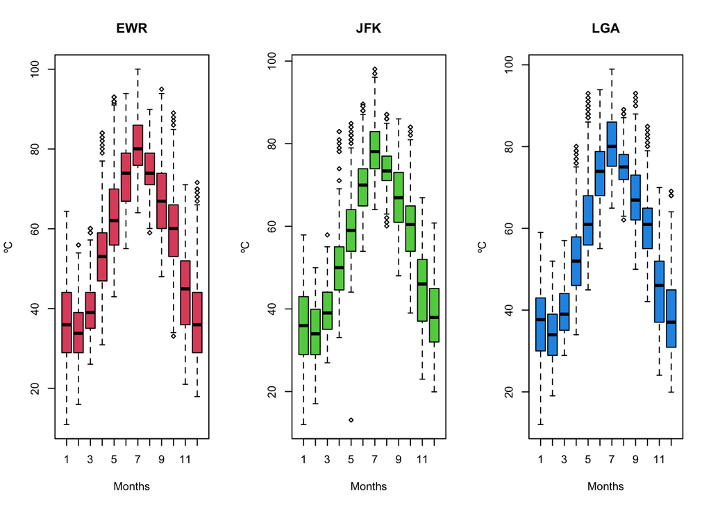

```
## [1] 55.54655 54.47215 55.76261
```

```r
plot_meteo(dat=LGA, meteo ="temp", mes= "month",titulo = "LGA", unidades = "ºC", color=4)
```

4. (2 puntos) El día de tu cumpleaños:
1. Qué correlación tuvieron la temperatura y humedad en cada uno de los origin? Plotealo mediante puntos con ggplot.

```r
cump_EWR= EWR[EWR$month== 9 & EWR$day== 29,]
cump_JFK= JFK[JFK$month== 9 & JFK$day== 29,]
cump_LGA= LGA[LGA$month== 9 & LGA$day== 29,]



cor(cump_EWR$temp, cump_EWR$humid)
```

```
## [1] -0.9621747
```

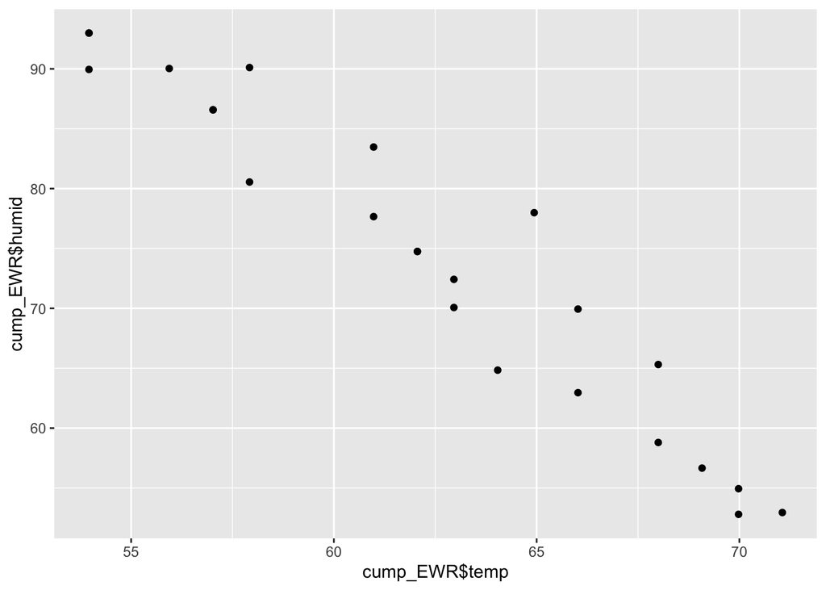

```r
ggplot(cump_EWR)+
  geom_point(aes(cump_EWR$temp, cump_EWR$humid))
```

```r
print("podemos observar tanto graficamente como mediante el test de correlacion que hay una correlación inversa, es decir, que a mayor temperatura hay menor humedad")
```

```
## [1] "podemos observar tanto graficamente como mediante el test de correlacion que hay una correlación inversa, es decir, que a mayor temperatura hay menor humedad"
```

```r
cor(cump_JFK$temp, cump_JFK$humid)
```

```
## [1] -0.9761018
```

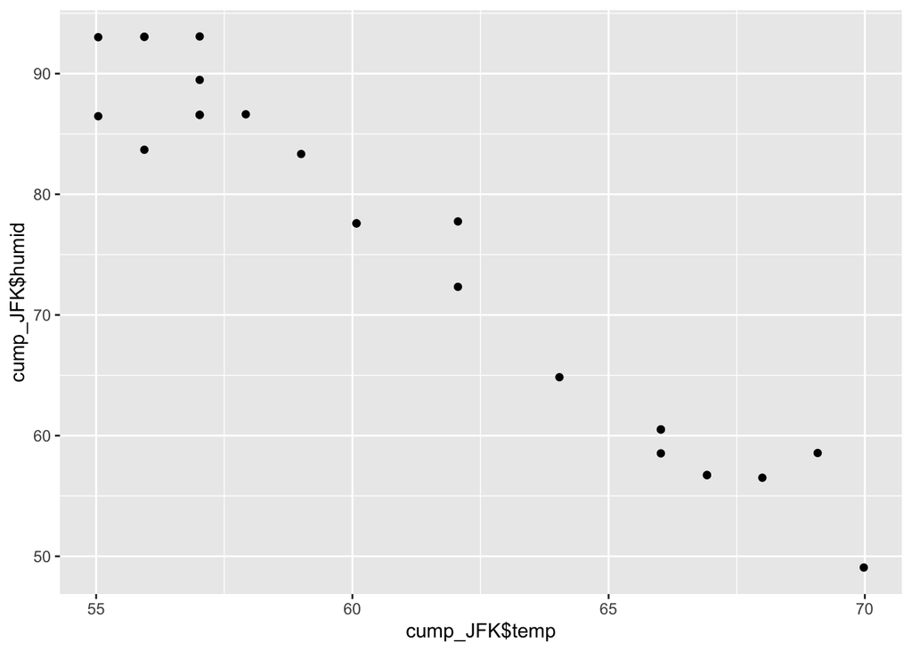

```r
ggplot(cump_JFK)+
  geom_point(aes(cump_JFK$temp, cump_JFK$humid))
```

```r
print("podemos observar tanto graficamente como mediante el test de correlacion que hay una correlación inversa, es decir, que a mayor temperatura hay menor humedad")
```

```
## [1] "podemos observar tanto graficamente como mediante el test de correlacion que hay una correlación inversa, es decir, que a mayor temperatura hay menor humedad"
```

```r
cor(cump_LGA$temp, cump_LGA$humid)
```

```
## [1] -0.8878584
```

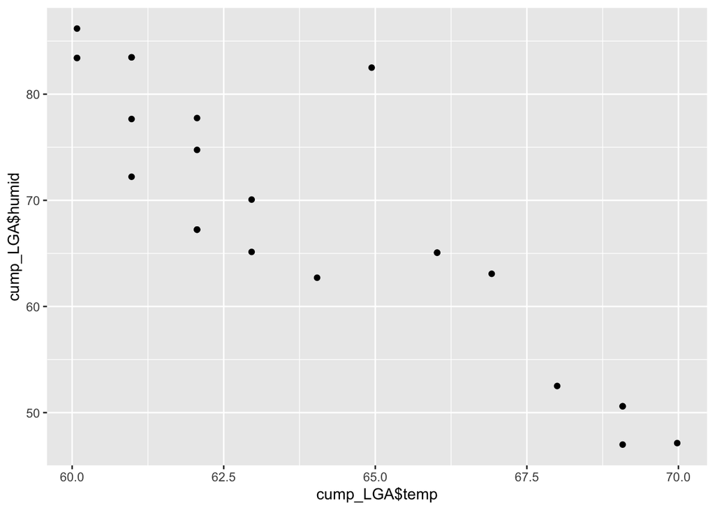

```r
ggplot(cump_LGA)+
  geom_point(aes(cump_LGA$temp, cump_LGA$humid))
```

```r
print("podemos observar tanto graficamente como mediante el test de correlacion que hay una correlación inversa, es decir, que a mayor temperatura hay menor humedad")
```

```
## [1] "podemos observar tanto graficamente como mediante el test de correlacion que hay una correlación inversa, es decir, que a mayor temperatura hay menor humedad"
```

```r
print("finalmente observamos que en todos los origin hay una correlacion inversa entre temperatura y humedad el día 29 de semptiembre")
```

```
## [1] "finalmente observamos que en todos los origin hay una correlacion inversa entre temperatura y humedad el día 29 de semptiembre"
```

2. Si comparas la temperatura en los origins JFK y LGA ¿son estadísticamente diferentes? ¿Qué p-valor consigues? Plotea los boxplots.

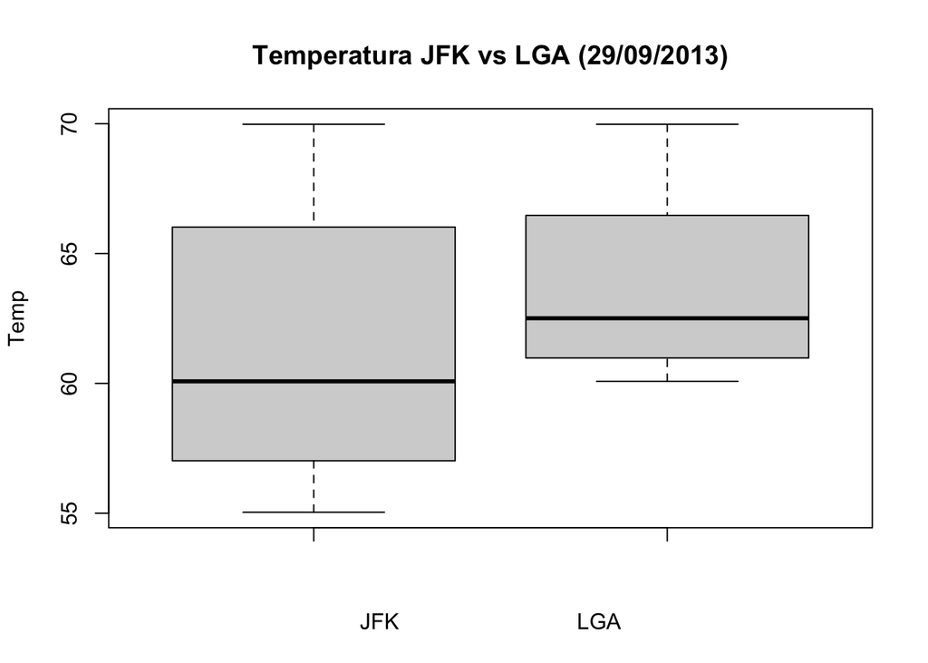

```r
par(mfrow = c(1,1))
T_test=t.test(cump_JFK$temp, cump_LGA$temp)
Pvalor_T=T_test$p.value
boxplot(cump_JFK$temp,cump_LGA$temp, main= "Temperatura JFK vs LGA (29/09/2013)", ylab= "Temp", xlab="JFK                             LGA")
```

```r
print(paste0("Como podemos ver las medias son diferentes siendo este hecho estadisticamente significativo debiado a que el p-valor es ", Pvalor_T))
```

```
## [1] "Como podemos ver las medias son diferentes siendo este hecho estadisticamente significativo debiado a que el p-valor es 0.0371126207911959"
```

```r
# El Fc más grande en valores absolutos es el punto que se encuentra más a la izquierda a la altura del 5 del eje de las "y"
# El gen sobreexpresado mas significativamente es el Rbp1
```

[output not shown]

6. (1 punto) Sube el examen a github y escribe a continuación tu url aquí.

```r
# el enlace es https://github.com/jonnn13/ExamenBioinformatica_2022.git
```